# R Notebook

To run this script: 1. Download HINTS 5 datasets from https://hints.cancer.gov/view-questions-topics/all-hints-questions.aspx to your data folder. Download all cycles of the data. 2. In the data folder, unzip each dataset. 3. Change the location parameter for the `get_hints5` call in the block below to point to your data folder. 4. Run this script.

```r
Sys.setenv(R_CONFIG_ACTIVE = Sys.info()["nodename"])

library(dplyr)
library(lavaan)
source("HINTS_preprocessing.R")
source("orfcs_utilities.R")
hints5 <-get_hints5(location=config::get("hints_protected_data_folderpath"))
```

```
## [1] "hints5_cycle2_public.sav"
## [1] TRUE
## [1] "PR_RUCA_2010TRUE"
## [1] "RUC2013TRUE"
## [1] TRUE
## [1] TRUE
## [1] "hints5_cycle1_public.sav"
## [1] TRUE
## [1] "PR_RUCA_2010TRUE"
## [1] "RUC2013TRUE"
## [1] TRUE
## [1] TRUE
## [1] "hints5_cycle3_public.sav"
## [1] TRUE
## [1] "PR_RUCA_2010TRUE"
## [1] "RUC2013TRUE"
## [1] TRUE
## [1] TRUE
## [1] "hints5_cycle4_public.sav"
## [1] TRUE
## [1] "PR_RUCA_2010TRUE"
## [1] "RUC2013TRUE"
## [1] TRUE
## [1] TRUE
```

```r
boot_times<-10000

zscore <- function(x){
    return((x-mean(x,na.rm=TRUE))/sd(x,na.rm=TRUE))
}
```

```r
# table(orfcs_dataset$RuralZIP_i,
#       orfcs_dataset$Gender3C,
#       orfcs_dataset$RaceCategorical=="HispanicAnyRace"
#       )
```

```r
sapply(c("Metropolitan", "Micropolitan", "Small town", "Rural"),
       function(cat){sum(grepl(cat,hints5$PR_RUCA_2010))}
       )
```

```
## Metropolitan Micropolitan   Small town        Rural
##        13912         1235          580          364
```

what’s the variability between men and women

including exercise or energy expenditure

exercise can improve objective health without/before it changes BMI.

weight physical activity and food intake

low income women, particularly low income women head of households, are of particular concern, and possibly hispanic women

```r
#table(orfcs_dataset$RuralZIP_i,
#      orfcs_dataset$Gender3C,
#      orfcs_dataset$RaceCategorical=="HispanicAnyRace"
#      )
```

```r
table(hints5$GeneralHealth_of) %>% cumsum / sum(!is.na(hints5$GeneralHealth_of))
```

```
## Excellent Very good      Good      Fair      Poor
## 0.1164388 0.4774746 0.8349820 0.9737887 1.0000000
```

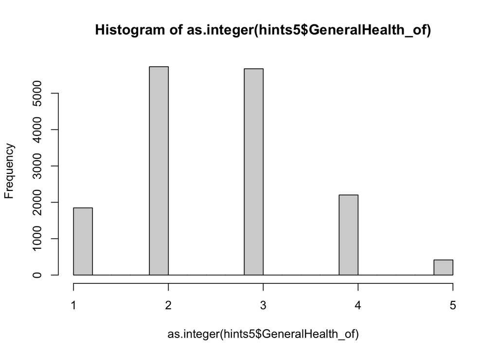

```r
hist(as.integer(hints5$GeneralHealth_of))
```

```r
library(magrittr)
library(dplyr)



data_dir <- config::get("rural_data_dir")

preprocessed_data_filepath <- paste0(data_dir,"cloudresearch_survey_results/orfcs_preprocessed2_anon_by_subj.csv")
library(readr)
library(ggplot2)
library(GGally)
orfcs_dataset <- readr::read_csv(preprocessed_data_filepath)
```

Let’s do our best to include all the same covariates we previously included.

# Prep

```r
library(stringi)
# [1] "Fruit_vegetables_z~HINTSIsRural_i+Age_c+I(Age_c^2)+RacePP+Gender3C+filename"
# [1] "MedConditions_HighBP_i~Fruit_vegetables_z+HINTSIsRural_i+Age_c+I(Age_c^2)+RacePP+Gender3C+filename"
# IncomeRanges_r

#need to do prepare variables so lavaan can process them
hints5_pp <- hints5
#add quadratic
hints5_pp$Age_c_pow2 <- hints5_pp$Age_c^2


#one-hot some variables
factor_to_clean_string <- function(data, col_to_stringify){
  data[[col_to_stringify]] <- as.character(data[[col_to_stringify]])
  data[[col_to_stringify]] <- (
    str_replace_all(data[[col_to_stringify]],"\\s","_") %>%
      str_replace_all("\\W","")
  )#table(hints5_pp[[col_to_stringify]])
  return(data)
}

hints5_pp<-factor_to_clean_string(hints5_pp,"RacePP2")
hints5_pp$RacePP2<-factor(hints5_pp$RacePP2)
hints5_pp <- mltools::one_hot(hints5_pp,"RacePP2",dropCols = FALSE)
print(paste0(colnames(hints5_pp)[grepl("RacePP2_",colnames(hints5_pp))],collapse=" + "))
```

```
## [1] "RacePP2_American_Indian_or_Alaska_Native + RacePP2_Asian_Indian + RacePP2_Black + RacePP2_Chinese + RacePP2_Filipino + RacePP2_Japanese + RacePP2_Korean + RacePP2_Missing_Data + RacePP2_Multiple_races_selected + RacePP2_Other_Asian + RacePP2_Pacific_Islander + RacePP2_Vietnamese + RacePP2_Wh…
```

```r
hints5_pp<-factor_to_clean_string(hints5_pp,"Hisp_Cat2")
hints5_pp$Hisp_Cat2<-factor(hints5_pp$Hisp_Cat2,levels=names(sort(table(hints5_pp$Hisp_Cat2),decreasing = TRUE)))
hints5_pp <- mltools::one_hot(hints5_pp,"Hisp_Cat2",dropCols = FALSE)
print(paste0(colnames(hints5_pp)[grepl("Hisp_Cat2_",colnames(hints5_pp))],collapse=" + "))
```

```
## [1] "Hisp_Cat2_Not_Hispanic + Hisp_Cat2_Unknown + Hisp_Cat2_Mexican + Hisp_Cat2_Other_Hispanic + Hisp_Cat2_Puerto_Rican + Hisp_Cat2_Multiple_Hispanic_ethnicities_selected + Hisp_Cat2_Cuban"
```

```r
hints5_pp<-factor_to_clean_string(hints5_pp,"Gender3C")
hints5_pp$Gender3C<-factor(hints5_pp$Gender3C)
hints5_pp <- mltools::one_hot(hints5_pp,"Gender3C",dropCols = FALSE)
print(paste0(colnames(hints5_pp)[grepl("Gender3C_",colnames(hints5_pp))],collapse=" + "))
```

```
## [1] "Gender3C_Female + Gender3C_Male + Gender3C_MissingOrMultiple"
```

Now prepare the ORFCS dataset for lavaan.

```r
#need to do prepare variables so lavaan can process them
orfcs_dataset_pp <- data.table(orfcs_dataset)
#add quadratic
orfcs_dataset_pp$DEMO_Age_c_pow2 <- orfcs_dataset_pp$DEMO_Age_c^2


#one-hot some variables


orfcs_dataset_pp<-factor_to_clean_string(orfcs_dataset_pp,"RaceC2")
orfcs_dataset_pp$RaceC2<-factor(orfcs_dataset_pp$RaceC2)
orfcs_dataset_pp <- mltools::one_hot(orfcs_dataset_pp,"RaceC2",dropCols = FALSE)
print(paste0(colnames(orfcs_dataset_pp)[grepl("RaceC2_",colnames(orfcs_dataset_pp))],collapse=" + "))
```

```
## [1] "RaceC2_Asian + RaceC2_HawaiianOtherPacificIslander + RaceC2_HispanicAnyRace + RaceC2_OtherRaceRaceNotReported + RaceC2_WhiteOnly"
```

```r
orfcs_dataset_pp<-factor_to_clean_string(orfcs_dataset_pp,"Gender3C")
orfcs_dataset_pp$Gender3C<-factor(orfcs_dataset_pp$Gender3C)
orfcs_dataset_pp <- mltools::one_hot(orfcs_dataset_pp,"Gender3C",dropCols = FALSE)
print(paste0(colnames(orfcs_dataset_pp)[grepl("Gender3C_",colnames(orfcs_dataset_pp))],collapse=" + "))
```

```
## [1] "Gender3C_Female + Gender3C_Male + Gender3C_Other"
```

# Oregon dataset: basic disparity

# HINTS dataset: two mediators

This follows Hayes PROCESS Model 6 with two mediators but we are doing it here in Lavaan.

Variables are:

- Treatment: Rurality
- Two Mediators: household income, and fruit and vegetable consumption, in that order.
- Outcome: Physical and health measures. Altogether, we’ll repeat the mediation several times, with the following outcomes variables: BMI, self-rated health, aggregated cardiometabolic health, and high blood pressure. (and cancer??)

This model below is adapted from https://towardsdatascience.com/doing-and-reporting-a-serial-mediation-model-with-two-mediators-in-r-with-lavaan-739ed3155814

I think they’ve left some things out. I need to do a bit more research to work out how to properly implement this, probably including a basic crash course in SEM.

For the basic HINTs lms, see `HINTS_health_outcomes.Rmd`.

```r
#TREAT=HINTSIsRural_i
#m1=IncomeRanges_r
#m2=Fruit_vegetables_z
#OUTCOME=MedConditions_HighBP_i


#NEXT TO DO: DEAL WITH CATEGORICAL DATA. GUIDE HERE: https://lavaan.ugent.be/tutorial/cat.html
hints_model_template=
"
  #Regressions
  IncomeRanges_r ~ ab*HINTSIsRural_i + Age_c + Age_c_pow2 + Gender3C_Male + Gender3C_MissingOrMultiple + RacePP2_American_Indian_or_Alaska_Native + RacePP2_Asian_Indian + RacePP2_Black + RacePP2_Chinese + RacePP2_Filipino + RacePP2_Japanese + RacePP2_Korean + RacePP2_Missing_Data + RacePP2_Multiple_races_selected + RacePP2_Other_Asian + RacePP2_Pacific_Islander + RacePP2_Vietnamese + Hisp_Cat2_Unknown + Hisp_Cat2_Mexican + Hisp_Cat2_Other_Hispanic + Hisp_Cat2_Puerto_Rican + Hisp_Cat2_Multiple_Hispanic_ethnicities_selected + Hisp_Cat2_Cuban

  Fruit_vegetables_z ~ bc*IncomeRanges_r + ac*HINTSIsRural_i + Age_c + Age_c_pow2 + Gender3C_Male + Gender3C_MissingOrMultiple + RacePP2_American_Indian_or_Alaska_Native + RacePP2_Asian_Indian + RacePP2_Black + RacePP2_Chinese + RacePP2_Filipino + RacePP2_Japanese + RacePP2_Korean + RacePP2_Missing_Data + RacePP2_Multiple_races_selected + RacePP2_Other_Asian + RacePP2_Pacific_Islander + RacePP2_Vietnamese + Hisp_Cat2_Unknown + Hisp_Cat2_Mexican + Hisp_Cat2_Other_Hispanic + Hisp_Cat2_Puerto_Rican + Hisp_Cat2_Multiple_Hispanic_ethnicities_selected + Hisp_Cat2_Cuban

  (OUTCOMEVAR) ~ cd*Fruit_vegetables_z + bd*IncomeRanges_r + ad*HINTSIsRural_i + Age_c + Age_c_pow2 + Gender3C_Male + Gender3C_MissingOrMultiple + RacePP2_American_Indian_or_Alaska_Native + RacePP2_Asian_Indian + RacePP2_Black + RacePP2_Chinese + RacePP2_Filipino + RacePP2_Japanese + RacePP2_Korean + RacePP2_Missing_Data + RacePP2_Multiple_races_selected + RacePP2_Other_Asian + RacePP2_Pacific_Islander + RacePP2_Vietnamese + Hisp_Cat2_Unknown + Hisp_Cat2_Mexican + Hisp_Cat2_Other_Hispanic + Hisp_Cat2_Puerto_Rican + Hisp_Cat2_Multiple_Hispanic_ethnicities_selected + Hisp_Cat2_Cuban


  #Defined Parameters:
  indirect_effect := ab*bc*cd
  effect_via_inc_only :=ab*bd
  effect_via_fruit_vege_only :=ac*cd
  direct_effect := ad
"

# - Outcome: Physical and health measures. Altogether, we'll repeat the mediation several times, with the following outcomes variables: BMI, self-rated health, aggregated cardiometabolic health, and high blood pressure.

outcome_measures <- c(
  "BMI",
  "GeneralHealth_i",
  "MedConditionsAggregate",
  "MedConditions_HighBP_i",
  "EverHadCancer_i"#no cancer for now, doesn't seem very important.
  )
```

```r
hints_fits_by_outcome<- list()

for (outcome_var in outcome_measures){
  set.seed(05711846)
  hints_model_w_outcome <- str_replace_all(hints_model_template,"\\(OUTCOMEVAR\\)",outcome_var)
  cat(paste0("MEDIATION MODEL FOR OUTCOME: ",outcome_var))
  cat(hints_model_w_outcome)
  fit=sem(
    hints_model_w_outcome,
    hints5_pp,
    se = "bootstrap",
    bootstrap=boot_times,
    likelihood = "wishart")

  hints_fits_by_outcome[[outcome_var]]<-fit
  summary(fit,ci=TRUE)
  cat("-----\n\n\n")
}
```

```
## MEDIATION MODEL FOR OUTCOME: BMI
##   #Regressions
##   IncomeRanges_r ~ ab*HINTSIsRural_i + Age_c + Age_c_pow2 + Gender3C_Male + Gender3C_MissingOrMultiple + RacePP2_American_Indian_or_Alaska_Native + RacePP2_Asian_Indian + RacePP2_Black + RacePP2_Chinese + RacePP2_Filipino + RacePP2_Japanese + RacePP2_Korean + RacePP2_Missing_Data + RacePP2_Multip…
##
##   Fruit_vegetables_z ~ bc*IncomeRanges_r + ac*HINTSIsRural_i + Age_c + Age_c_pow2 + Gender3C_Male + Gender3C_MissingOrMultiple + RacePP2_American_Indian_or_Alaska_Native + RacePP2_Asian_Indian + RacePP2_Black + RacePP2_Chinese + RacePP2_Filipino + RacePP2_Japanese + RacePP2_Korean + RacePP2_Missi…
##
##   BMI ~ cd*Fruit_vegetables_z + bd*IncomeRanges_r + ad*HINTSIsRural_i + Age_c + Age_c_pow2 + Gender3C_Male + Gender3C_MissingOrMultiple + RacePP2_American_Indian_or_Alaska_Native + RacePP2_Asian_Indian + RacePP2_Black + RacePP2_Chinese + RacePP2_Filipino + RacePP2_Japanese + RacePP2_Korean + Race…
##
##
##   #Defined Parameters:
##   indirect_effect := ab*bc*cd
##   effect_via_inc_only :=ab*bd
##   effect_via_fruit_vege_only :=ac*cd
##   direct_effect := ad
## lavaan 0.6-11 ended normally after 1 iterations
##
##   Estimator                                         ML
##   Optimization method                           NLMINB
##   Number of model parameters                        75
##
##                                                   Used       Total
##   Number of observations                          6231       16092
##
## Model Test User Model:
##
##   Test statistic                                 0.000
##   Degrees of freedom                                 0
##
## Parameter Estimates:
##
##   Standard errors                            Bootstrap
##   Number of requested bootstrap draws            10000
##   Number of successful bootstrap draws           10000
##
## Regressions:
##                        Estimate    Std.Err  z-value  P(>|z|) ci.lower
##   IncomeRanges_r ~
##     HINTSIsR_ (ab)         -0.761    0.080   -9.532    0.000     -0.917
##     Age_c                   0.011    0.003    3.291    0.001      0.005
##     Age_c_pw2              -0.001    0.000  -11.144    0.000     -0.001
```

[output cut: 963 more lines]

```
##
## Variances:
##                    Estimate    Std.Err  z-value  P(>|z|) ci.lower   ci.upper
##    .IncomeRanges_r      4.343    0.069   62.628    0.000      4.190      4.465
##    .Fruit_vgtbls_z      0.944    0.016   57.978    0.000      0.909      0.972
##    .EverHadCancer_      0.117    0.003   43.274    0.000      0.111      0.122
##
## Defined Parameters:
##                    Estimate    Std.Err  z-value  P(>|z|) ci.lower   ci.upper
##     indirect_effct     -0.000    0.000   -0.913    0.361     -0.001      0.000
##     effct_v_nc_nly     -0.001    0.002   -0.881    0.378     -0.005      0.002
##     effct_v_frt_v_     -0.000    0.000   -0.728    0.467     -0.001      0.000
##     direct_effect      -0.015    0.013   -1.092    0.275     -0.041      0.012
##
## -----
```

```r
#
# set.seed(05711846)
#
# fit=sem(
#   hints_model,
#   hints5_pp,
#   se = "bootstrap",
#   bootstrap=1000,
#   likelihood = "wishart")
# summary(fit)
```

# Oregon dataset: three mediators

For comparison with HINTS, we’ll first repeat the HINTS dataset two-mediator model as described above, but using three mediators.

Then, we’ll proceed with our main Oregon dataset analysis.

This follows Hayes PROCESS Model 6 with THREE mediators but we are doing it here in Lavaan.

Variables are:

- Treatment: Rurality
- Two Mediators: household income, MESA healthy food availability, and fruit and vegetable consumption, in that order.
- Outcome: Physical and health measures. Altogether, we’ll repeat the mediation several times, with the following outcomes variables: BMI, self-rated health, aggregated cardiometabolic health, and high blood pressure.

```r
#TREAT=HINTSIsRural_i
#m1=IncomeRanges_r
#m2=Fruit_vegetables_z
#OUTCOME=MedConditions_HighBP_i


# mb <- lm(MESA_healthyfoodavailability_z~RuralZIP_i+Gender3C+DEMO_Age_c+RaceC2+PSS_z,data_to_measure)
# mc <- lm(BMI~RuralZIP_i+Gender3C+DEMO_Age_c+RaceC2+MESA_healthyfoodavailability_z+PSS_z,data_to_measure)

# [1] "RaceC2_Asian + RaceC2_HawaiianOtherPacificIslander + RaceC2_HispanicAnyRace + RaceC2_OtherRaceRaceNotReported + RaceC2_WhiteOnly"
# [1] "Gender3C_Female + Gender3C_Male + Gender3C_Other"

#NEXT TO DO: DEAL WITH CATEGORICAL DATA. GUIDE HERE: https://lavaan.ugent.be/tutorial/cat.html
oregon_model_template=
"
  #Regressions
  aSES_02_z ~ ab*RuralZIP_i + DEMO_Age_c + DEMO_Age_c_pow2 + Gender3C_Male + Gender3C_Other + RaceC2_Asian + RaceC2_HawaiianOtherPacificIslander + RaceC2_HispanicAnyRace + RaceC2_OtherRaceRaceNotReported

  MESA_healthyfoodavailability_z ~ bc*aSES_02_z + ac*RuralZIP_i + DEMO_Age_c + DEMO_Age_c_pow2 + Gender3C_Male + Gender3C_Other + RaceC2_Asian + RaceC2_HawaiianOtherPacificIslander + RaceC2_HispanicAnyRace + RaceC2_OtherRaceRaceNotReported

  FFQ_fruit_vegetables_z ~ cd*MESA_healthyfoodavailability_z + bd*aSES_02_z + ad*RuralZIP_i + DEMO_Age_c + DEMO_Age_c_pow2 + Gender3C_Male + Gender3C_Other + RaceC2_Asian + RaceC2_HawaiianOtherPacificIslander + RaceC2_HispanicAnyRace + RaceC2_OtherRaceRaceNotReported

  (OUTCOMEVAR) ~ de*FFQ_fruit_vegetables_z + ce*MESA_healthyfoodavailability_z + be*aSES_02_z + ae*RuralZIP_i + DEMO_Age_c + DEMO_Age_c_pow2 + Gender3C_Male + Gender3C_Other + RaceC2_Asian + RaceC2_HawaiianOtherPacificIslander + RaceC2_HispanicAnyRace + RaceC2_OtherRaceRaceNotReported


  #Defined Parameters:
  indirect_effect := ab*bc*cd*de
  effect_via_food := ac*cd*de
  effect_via_income := ab*be
  effect_via_inc_eating := ab*bd*de
  effect_via_eating := ad*de
  direct_effect := ae
"

# - Outcome: Physical and health measures. Altogether, we'll repeat the mediation several times, with the following outcomes variables: BMI, self-rated health, aggregated cardiometabolic health, and high blood pressure.

outcome_measures <- c(
  "BMI"#,
  #"GeneralHealth_i",
  #"MedConditionsAggregate",
  #"MedConditions_HighBP_i",
  #"EverHadCancer_i"#no cancer for now, doesn't seem very important.
  )
```

```r
# for (outcome_var in outcome_measures){
set.seed(8233042)
outcome_var <- "BMI"
oregon_model_w_outcome <- str_replace_all(oregon_model_template,"\\(OUTCOMEVAR\\)",outcome_var)
cat(paste0("MEDIATION MODEL FOR OUTCOME: ",outcome_var))
```

```
## MEDIATION MODEL FOR OUTCOME: BMI
```

```r
cat(oregon_model_w_outcome)
```

```
##
##   #Regressions
##   aSES_02_z ~ ab*RuralZIP_i + DEMO_Age_c + DEMO_Age_c_pow2 + Gender3C_Male + Gender3C_Other + RaceC2_Asian + RaceC2_HawaiianOtherPacificIslander + RaceC2_HispanicAnyRace + RaceC2_OtherRaceRaceNotReported
##
##   MESA_healthyfoodavailability_z ~ bc*aSES_02_z + ac*RuralZIP_i + DEMO_Age_c + DEMO_Age_c_pow2 + Gender3C_Male + Gender3C_Other + RaceC2_Asian + RaceC2_HawaiianOtherPacificIslander + RaceC2_HispanicAnyRace + RaceC2_OtherRaceRaceNotReported
##
##   FFQ_fruit_vegetables_z ~ cd*MESA_healthyfoodavailability_z + bd*aSES_02_z + ad*RuralZIP_i + DEMO_Age_c + DEMO_Age_c_pow2 + Gender3C_Male + Gender3C_Other + RaceC2_Asian + RaceC2_HawaiianOtherPacificIslander + RaceC2_HispanicAnyRace + RaceC2_OtherRaceRaceNotReported
##
##   BMI ~ de*FFQ_fruit_vegetables_z + ce*MESA_healthyfoodavailability_z + be*aSES_02_z + ae*RuralZIP_i + DEMO_Age_c + DEMO_Age_c_pow2 + Gender3C_Male + Gender3C_Other + RaceC2_Asian + RaceC2_HawaiianOtherPacificIslander + RaceC2_HispanicAnyRace + RaceC2_OtherRaceRaceNotReported
##
##
##   #Defined Parameters:
##   indirect_effect := ab*bc*cd*de
##   effect_via_food := ac*cd*de
##   effect_via_income := ab*be
##   effect_via_inc_eating := ab*bd*de
##   effect_via_eating := ad*de
##   direct_effect := ae
```

```r
orfcs_fit=sem(
  oregon_model_w_outcome,
  orfcs_dataset_pp,
  se = "bootstrap",
  bootstrap=boot_times,
  likelihood = "wishart")
```

[output not shown]

```r
summary(orfcs_fit,ci=TRUE)
```

```
## lavaan 0.6-11 ended normally after 1 iterations
##
##   Estimator                                         ML
##   Optimization method                           NLMINB
##   Number of model parameters                        46
##
##                                                   Used       Total
##   Number of observations                           618         850
##
## Model Test User Model:
##
##   Test statistic                                 0.000
##   Degrees of freedom                                 0
##
## Parameter Estimates:
##
##   Standard errors                            Bootstrap
##   Number of requested bootstrap draws            10000
##   Number of successful bootstrap draws            9923
##
## Regressions:
##                                    Estimate        Std.Err  z-value  P(>|z|)
##   aSES_02_z ~
##     RuralZIP_ (ab)                         -0.352    0.078   -4.496    0.000
##     DEMO_Ag_c                               0.001    0.002    0.496    0.620
##     DEMO_A__2                              -0.000    0.000   -0.008    0.993
##     Gndr3C_Ml                               0.352    0.087    4.053    0.000
##     Gndr3C_Ot                               0.026    0.347    0.074    0.941
##     RacC2_Asn                              -0.214    0.163   -1.310    0.190
##     RcC2_HOPI                               0.304    0.253    1.204    0.229
##     RcC2_HsAR                               0.097    0.178    0.548    0.584
##     RC2_ORRNR                               0.703    0.196    3.596    0.000
##   MESA_healthyfoodavailability_z ~
##     aSES_02_z (bc)                          0.167    0.040    4.166    0.000
##     RuralZIP_ (ac)                         -0.272    0.086   -3.156    0.002
##     DEMO_Ag_c                               0.006    0.002    3.085    0.002
##     DEMO_A__2                              -0.000    0.000   -0.069    0.945
##     Gndr3C_Ml                              -0.057    0.087   -0.656    0.512
##     Gndr3C_Ot                              -0.082    0.336   -0.245    0.806
##     RacC2_Asn                               0.391    0.139    2.805    0.005
```

[output cut: 88 more lines]

```
## Defined Parameters:
##                    Estimate        Std.Err  z-value  P(>|z|) ci.lower
##     indirect_effct          0.009    0.005    1.937    0.053          0.002
##     effect_via_fod          0.041    0.021    1.935    0.053          0.008
##     effect_via_ncm          0.350    0.139    2.514    0.012          0.138
##     effct_v_nc_tng          0.014    0.016    0.891    0.373         -0.012
##     effect_via_tng         -0.109    0.091   -1.191    0.234         -0.320
##     direct_effect           1.583    0.630    2.511    0.012          0.268
##  ci.upper
##           0.019
##           0.090
##           0.683
##           0.053
##           0.044
##           2.755
```

```r
  # cat("-----\n\n\n")
# }
```

# Hybrid: three mediators

This follows Hayes PROCESS Model 6 with THREE mediators. We need to somehow manually combine the two datasets by multiplying effects. Need to follow bootstrap analysis, which means we need to extract raw bootstrap results and combine them. I’m not sure it’s feasible, but it would be quite valuable to do.

Variables are:

- Treatment: Rurality
- Two Mediators: household income, MESA healthy food availability, and fruit and vegetable consumption, in that order.
- Outcome: Physical and health measures. Altogether, we’ll repeat the mediation several times, with the following outcomes variables: BMI, self-rated health, aggregated cardiometabolic health, and high blood pressure.

## Hybrid Analysis run

```r
get_fit_PE<-function(fit_to_read){
  sink("temp_out.txt")
  fit_pe<-summary(fit_to_read,ci=TRUE)$PE
  sink(NULL)
  return(fit_pe)
}

lavaan_results_list <- list()
for (hints_fit_label in names(hints_fits_by_outcome)){
  hints_fit<-hints_fits_by_outcome[[hints_fit_label]]
  lavaan_summarized_results <- get_fit_PE(hints_fit) %>% filter(label!="")
  lavaan_summarized_results[["outcome"]]<-hints_fit_label
  lavaan_results_list<-append(lavaan_results_list,list(lavaan_summarized_results))
}
lavaan_results_df <- do.call(rbind,lavaan_results_list)
```

```r
summarize_calculated_effect <- function(effect_vector){
    effect_mean <- mean(effect_vector)
    effect_se <- sd(effect_vector)
    effect_ci_lower <- quantile(effect_vector,0.025)
    effect_ci_upper <- quantile(effect_vector,0.975)
    #the z-value here is exactly what lavaan displays.
    #it's going to be a bit different
    #because the mean and se I get are both a bit different for reasons that are unclear to me.
    effect_z_value <- effect_mean/effect_se
    effect_p_value <- get_two_tailed_score(effect_z_value)

    cat(paste("Estimate=",signif(effect_mean,4),", Std. Err=",signif(effect_se,4),", z-value=",signif(effect_z_value,4), ", p-value=",signif(effect_p_value,4)))
    cat("\n")

    return(data.frame(
      "est"=effect_mean,
      "se"=effect_se,
      "pvalue"=effect_p_value,
      "ci_lower" = effect_ci_lower,
      "ci_upper" = effect_ci_upper
    ))
    #print(t.test(hybrid_indirect_effect))
    #cat("\n")
  }

orfcs_boot<-extract_and_label_bootstrap_results(orfcs_fit)
```

```
## lavaan 0.6-11 ended normally after 1 iterations
##
##   Estimator                                         ML
##   Optimization method                           NLMINB
##   Number of model parameters                        46
##
##                                                   Used       Total
##   Number of observations                           618         850
##
## Model Test User Model:
##
##   Test statistic                                 0.000
##   Degrees of freedom                                 0
##
## Parameter Estimates:
##
##   Standard errors                            Bootstrap
##   Number of requested bootstrap draws            10000
##   Number of successful bootstrap draws            9923
##
## Regressions:
##                                    Estimate        Std.Err  z-value  P(>|z|)
##   aSES_02_z ~
##     RuralZIP_ (ab)                         -0.352    0.078   -4.496    0.000
##     DEMO_Ag_c                               0.001    0.002    0.496    0.620
##     DEMO_A__2                              -0.000    0.000   -0.008    0.993
##     Gndr3C_Ml                               0.352    0.087    4.053    0.000
##     Gndr3C_Ot                               0.026    0.347    0.074    0.941
##     RacC2_Asn                              -0.214    0.163   -1.310    0.190
##     RcC2_HOPI                               0.304    0.253    1.204    0.229
##     RcC2_HsAR                               0.097    0.178    0.548    0.584
##     RC2_ORRNR                               0.703    0.196    3.596    0.000
##   MESA_healthyfoodavailability_z ~
##     aSES_02_z (bc)                          0.167    0.040    4.166    0.000
##     RuralZIP_ (ac)                         -0.272    0.086   -3.156    0.002
##     DEMO_Ag_c                               0.006    0.002    3.085    0.002
##     DEMO_A__2                              -0.000    0.000   -0.069    0.945
##     Gndr3C_Ml                              -0.057    0.087   -0.656    0.512
##     Gndr3C_Ot                              -0.082    0.336   -0.245    0.806
##     RacC2_Asn                               0.391    0.139    2.805    0.005
```

[output cut: 91 more lines]

```
##     effect_via_fod          0.041    0.021    1.935    0.053          0.008
##     effect_via_ncm          0.350    0.139    2.514    0.012          0.138
##     effct_v_nc_tng          0.014    0.016    0.891    0.373         -0.012
##     effect_via_tng         -0.109    0.091   -1.191    0.234         -0.320
##     direct_effect           1.583    0.630    2.511    0.012          0.268
##  ci.upper
##           0.019
##           0.090
##           0.683
##           0.053
##           0.044
##           2.755
##
## [1] 97
## [1] 9923   46
```

```r
colnames(orfcs_boot)<-
  paste0("orfcs_",colnames(orfcs_boot))

hybrid_effect_list <-list()
for (effect_name in names(hints_fits_by_outcome)){
  cat(paste0("HYBRID INDIRECT EFFECT FOR: ",effect_name,"\n\n"))
  hints_boot <-extract_and_label_bootstrap_results(hints_fits_by_outcome[[effect_name]])
  # sink("temp_diversion.txt")
  # lavaan_computed_indirect_effect <- (
  #   summary(hints_fits_by_outcome[[effect_name]])$PE %>% filter(label=="indirect_effect")
  # )
  # sink(NULL)
  colnames(hints_boot)<-
    paste0("hints_",colnames(hints_boot))


  row_count <- min(nrow(orfcs_boot),nrow(hints_boot))
  combined_boot_results <- data.frame(cbind(orfcs_boot[1:row_count,],hints_boot[1:row_count,]))



  # cat("HINTS lavaan pre-computed indirect effect:\n")
  # cat(paste(names(lavaan_computed_indirect_effect),collapse="\t"))
  # cat(paste(lavaan_computed_indirect_effect,collapse="\t"))
  #
  # cat("\n")

  cat("HINTS indirect effect:\n ")
  HINTS_indirect_effect <- apply(combined_boot_results %>% select(hints_ab, hints_bc, hints_cd),1,prod)
  summarize_calculated_effect(HINTS_indirect_effect)


  cat("Hybrid indirect effect:\n ")
  hybrid_indirect_effect <- apply(combined_boot_results %>% select(hints_ab, orfcs_bc,orfcs_cd, hints_cd),1,prod)
  hie_result <- summarize_calculated_effect(hybrid_indirect_effect)
  hybrid_effect_set<-list("indirect_effect"=hie_result)

  cat("Hybrid effect via food availability and consumption:\n ")
  hybrid_indirect_effect <- apply(combined_boot_results %>% select(orfcs_ac,orfcs_cd, hints_cd),1,prod)
  hie_result <- summarize_calculated_effect(hybrid_indirect_effect)
  hybrid_effect_set <- append(hybrid_effect_set,list("availability_consumption"=hie_result))

  cat("Hybrid effect via food consumption (independently of availability):\n ")
  hybrid_indirect_effect <- apply(combined_boot_results %>% select(orfcs_ad,hints_cd),1,prod)
  hie_result <- summarize_calculated_effect(hybrid_indirect_effect)
  hybrid_effect_set <- append(hybrid_effect_set,list("consumption_alone"=hie_result))

  hybrid_effect_set_df <- do.call(rbind,hybrid_effect_set)
  hybrid_effect_set_df$outcome<-effect_name
  hybrid_effect_set_df$pathway <- rownames(hybrid_effect_set_df)

  hybrid_effect_list<-append(hybrid_effect_list,list(hybrid_effect_set_df))
  cat("---------\n\n\n")

}
```

```
## HYBRID INDIRECT EFFECT FOR: BMI
##
## lavaan 0.6-11 ended normally after 1 iterations
##
##   Estimator                                         ML
##   Optimization method                           NLMINB
##   Number of model parameters                        75
##
##                                                   Used       Total
##   Number of observations                          6231       16092
##
## Model Test User Model:
##
##   Test statistic                                 0.000
##   Degrees of freedom                                 0
##
## Parameter Estimates:
##
##   Standard errors                            Bootstrap
##   Number of requested bootstrap draws            10000
##   Number of successful bootstrap draws           10000
##
## Regressions:
##                        Estimate    Std.Err  z-value  P(>|z|) ci.lower
##   IncomeRanges_r ~
##     HINTSIsR_ (ab)         -0.761    0.080   -9.532    0.000     -0.917
##     Age_c                   0.011    0.003    3.291    0.001      0.005
##     Age_c_pw2              -0.001    0.000  -11.144    0.000     -0.001
##     Gndr3C_Ml               0.455    0.054    8.387    0.000      0.348
##     Gnd3C_MOM              -0.792    0.148   -5.361    0.000     -1.087
##     RPP2_A_I_              -0.857    0.398   -2.155    0.031     -1.645
##     RcPP2_A_I               0.513    0.219    2.346    0.019      0.081
##     RcPP2_Blc              -1.458    0.083  -17.657    0.000     -1.619
##     RcPP2_Chn              -0.017    0.276   -0.060    0.952     -0.558
##     RcPP2_Flp               0.151    0.223    0.676    0.499     -0.301
##     RcPP2_Jpn               0.824    0.328    2.512    0.012      0.151
##     RcPP2_Krn               0.140    0.396    0.353    0.724     -0.648
##     RcPP2_M_D              -0.557    0.162   -3.435    0.001     -0.881
##     RcPP2_M__              -0.864    0.148   -5.828    0.000     -1.154
##     RcPP2_O_A              -0.593    0.307   -1.929    0.054     -1.228
```

[output cut: 953 more lines]

```
##     effct_v_nc_nly     -0.001    0.002   -0.881    0.378     -0.005      0.002
##     effct_v_frt_v_     -0.000    0.000   -0.728    0.467     -0.001      0.000
##     direct_effect      -0.015    0.013   -1.092    0.275     -0.041      0.012
##
## [1] 355
## [1] 10000    75
## HINTS indirect effect:
##  Estimate= -0.0002551 , Std. Err= 0.0002786 , z-value= -0.9157 , p-value= 0.3598
## Hybrid indirect effect:
##  Estimate= -8.08e-05 , Std. Err= 9.718e-05 , z-value= -0.8314 , p-value= 0.4057
## Hybrid effect via food availability and consumption:
##  Estimate= -0.000181 , Std. Err= 0.0002267 , z-value= -0.7981 , p-value= 0.4248
## Hybrid effect via food consumption (independently of availability):
##  Estimate= 0.0004997 , Std. Err= 0.0007487 , z-value= 0.6674 , p-value= 0.5045
## ---------
```

```r
hybrid_effect_df<-do.call(rbind,hybrid_effect_list)
```

## Notes

On its face, this “hybrid effect” shows that if we assume relationships between (a) household income and health food availability and (b) health food availability and fruit and veggie consumption are the same in the HINTS population as they are in the ORFCS population, then rurality has an indirect effect through health food availability in HINTS, too.

# Summarizing the HINTS dataset results

Because there are quite a lot of results here, we should probably summarize them in a table.

```r
save.image(file="sequential_boot_10.Rdata")
```

```r
p_value_asterisks<-function(pvalue){
  p_value_asterisks_by_scalar <- function(pvalue){
    if (pvalue<0.001){
    return("***")
  }else if (pvalue<0.01){
    return("**")
  }else if (pvalue<0.05){
    return("*")
  }else if (pvalue<0.1){
    return("+")
  }
  return("")
  }
  return(sapply(pvalue,p_value_asterisks_by_scalar))
}
library(papaja)
library(kableExtra)
library(dplyr)
```

```r
p_value_asterisks<-function(pvalue){
  p_value_asterisks_by_scalar <- function(pvalue){
    if (pvalue<0.001){
    return("***")
  }else if (pvalue<0.01){
    return("**")
  }else if (pvalue<0.05){
    return("*")
  }else if (pvalue<0.1){
    return("⁺")
  }
  return("")
  }
  return(sapply(pvalue,p_value_asterisks_by_scalar))
}


formatB<-function(num,digits=digits){
  #FormatBen
  #return(str_replace(format(round(num,digits=digits),justify="right",scientific=FALSE)," ","&nbsp;"))
  return(format(round(num,digits=digits),scientific=FALSE))
}

num_w_p <- function(num, pvalue,digits=2){

  return(paste0(formatB(num,digits=digits),p_value_asterisks(pvalue)))
}
#can use this function for all sorts of labels, not just a particular kind
label_rename<-function(label){
  #effect routes
  label[label=="effect_via_fruit_vege_only"]<-"Via fruit and vegetable consumption"
  label[label=="effect_via_inc_only"]<-"Via income only"
  label[label=="availability_consumption"]<-"Via fruit and vegetable availability and consumption"
  label[label=="consumption_alone"]<-"Via fruit and vegetable consumption alone"

  #Outcome labels
  label[label=="GeneralHealth_i"] <- "Self-rated health"
  label[label=="MedConditionsAggregate"] <- "Aggregate cardiometabolic health"
  label[label=="MedConditions_HighBP_i"] <- "High blood pressure/hypertension"
  label[label=="EverHadCancer_i"] <- "Ever had cancer"
  #BMI"                    "GeneralHealth_i"        "MedConditionsAggregate" "MedConditions_HighBP_i" "EverHadCancer_i"


  #misc
  label <- sapply(
    label,
    function(l){
      if(l=="BMI") return(l)
      return(str_replace_all(l,"_"," ") %>% str_to_sentence)
    }
  )

  return(label)
}
```

```r
kable_input <- lavaan_results_df %>% filter(label %in% c(
    "indirect_effect",
  "direct_effect",
  "effect_via_inc_only",
  "effect_via_fruit_vege_only")) %>%
  mutate(Pathway = label_rename(label),
         Outcome = label_rename(outcome),
         Estimate = num_w_p(est,pvalue,digits=4),
         SE=formatB(se,digits=4)) %>%
  arrange(outcome) %>%
  select(Pathway, Outcome,Estimate,SE) %>% arrange(Pathway)

groups_df <- kable_input %>%
  group_by(Pathway) %>%
    summarize(group_start=length(Pathway))

groups<-groups_df$group_start
names(groups)<-groups_df$Pathway

kable_out <- kable_input %>%
  select(-Pathway) %>%
  knitr::kable() %>%
  kable_classic(full_width = F,html_font="Times New Roman") %>%
  pack_rows(index=groups)


#knitr::asis_output(str_replace(kable_out,"\\+","\\^\\+"))

kable_out
```

| Outcome | Estimate | SE |
| --- | --- | --- |
| **Direct effect** |  |  |
| BMI | 0.9605*** | 0.2713 |
| Ever had cancer | -0.0146 | 0.0134 |
| Self-rated health | 0.0614⁺ | 0.0351 |
| High blood pressure/hypertension | 0.0242 | 0.0177 |
| Aggregate cardiometabolic health | 0.0383 | 0.0303 |
| **Indirect effect** |  |  |
| BMI | 0.0375*** | 0.0070 |
| Ever had cancer | -0.0003 | 0.0003 |
| Self-rated health | 0.0093*** | 0.0014 |
| High blood pressure/hypertension | 0.0009* | 0.0004 |
| Aggregate cardiometabolic health | 0.0021** | 0.0007 |
| **Via fruit and vegetable consumption** |  |  |
| BMI | 0.0394 | 0.0246 |
| Ever had cancer | -0.0003 | 0.0004 |
| Self-rated health | 0.0103⁺ | 0.0058 |
| High blood pressure/hypertension | 0.0010 | 0.0007 |
| Aggregate cardiometabolic health | 0.0021 | 0.0015 |
| **Via income only** |  |  |
| BMI | 0.2184*** | 0.0392 |
| Ever had cancer | -0.0014 | 0.0016 |
| Self-rated health | 0.0853*** | 0.0100 |
| High blood pressure/hypertension | 0.0178*** | 0.0028 |
| Aggregate cardiometabolic health | 0.0414*** | 0.0058 |

# Summarizing the hybrid dataset results

```r
kable_input <- hybrid_effect_df %>%
  #mutate(pv = p_value_asterisks(pvalue)) %>%
  mutate(Pathway = label_rename(pathway),
         Outcome = label_rename(outcome),
         Estimate = num_w_p(est,pvalue,digits=4),
         SE=formatB(se,digits=4)) %>%
  select(Pathway, Outcome,Estimate,SE) %>% arrange(Pathway)

groups_df <- kable_input %>%
  group_by(Pathway) %>%
    summarize(group_start=length(Outcome))

groups<-groups_df$group_start
names(groups)<-groups_df$Pathway

rownames(kable_input)<-NULL
kable_input %>%
  select(-Pathway) %>%
  knitr::kable() %>%
  kable_classic(full_width = F,html_font="Times New Roman") %>%

  #pack_rows(index=c("indirect_effect"=nrow(kable_input)))
  pack_rows(index=groups)
```

| Outcome | Estimate | SE |
| --- | --- | --- |
| **Indirect effect** |  |  |
| BMI | 0.0119* | 0.0047 |
| Self-rated health | 0.0029** | 0.0011 |
| Aggregate cardiometabolic health | 0.0007* | 0.0003 |
| High blood pressure/hypertension | 0.0003⁺ | 0.0002 |
| Ever had cancer | -0.0001 | 0.0001 |
| **Via fruit and vegetable availability and consumption** |  |  |
| BMI | 0.0268* | 0.0122 |
| Self-rated health | 0.0066* | 0.0029 |
| Aggregate cardiometabolic health | 0.0015⁺ | 0.0008 |
| High blood pressure/hypertension | 0.0006 | 0.0004 |
| Ever had cancer | -0.0002 | 0.0002 |
| **Via fruit and vegetable consumption alone** |  |  |
| BMI | -0.0740 | 0.0540 |
| Self-rated health | -0.0181 | 0.0130 |
| Aggregate cardiometabolic health | -0.0042 | 0.0033 |
| High blood pressure/hypertension | -0.0018 | 0.0015 |
| Ever had cancer | 0.0005 | 0.0007 |

# Investigating additional factors

## household income

We probably could get household income from ORFCS because we have ZIP codes. First we need to get some mean data…

```r
orfcs_dataset_pp$ZipcodeMedianHouseholdIncome_c <-
  orfcs_dataset_pp$ZipcodeMedianHouseholdIncome - mean(orfcs_dataset_pp$ZipcodeMedianHouseholdIncome,na.rm=TRUE)

orfcs_dataset_pp$ZipcodeMedianHouseholdIncome_z <-
  zscore(orfcs_dataset_pp$ZipcodeMedianHouseholdIncome)
```

now we have it…

```r
#TREAT=HINTSIsRural_i
#m1=IncomeRanges_r
#m2=Fruit_vegetables_z
#OUTCOME=MedConditions_HighBP_i


# mb <- lm(MESA_healthyfoodavailability_z~RuralZIP_i+Gender3C+DEMO_Age_c+RaceC2+PSS_z,data_to_measure)
# mc <- lm(BMI~RuralZIP_i+Gender3C+DEMO_Age_c+RaceC2+MESA_healthyfoodavailability_z+PSS_z,data_to_measure)

# [1] "RaceC2_Asian + RaceC2_HawaiianOtherPacificIslander + RaceC2_HispanicAnyRace + RaceC2_OtherRaceRaceNotReported + RaceC2_WhiteOnly"
# [1] "Gender3C_Female + Gender3C_Male + Gender3C_Other"

#NEXT TO DO: DEAL WITH CATEGORICAL DATA. GUIDE HERE: https://lavaan.ugent.be/tutorial/cat.html
oregon_model_with_zipinc=
"
  #Regressions
  ZipcodeMedianHouseholdIncome_z ~ ab*RuralZIP_i + DEMO_Age_c + DEMO_Age_c_pow2 + Gender3C_Male + Gender3C_Other + RaceC2_Asian + RaceC2_HawaiianOtherPacificIslander + RaceC2_HispanicAnyRace + RaceC2_OtherRaceRaceNotReported

  MESA_healthyfoodavailability_z ~ bc*ZipcodeMedianHouseholdIncome_z + ac*RuralZIP_i + DEMO_Age_c + DEMO_Age_c_pow2 + Gender3C_Male + Gender3C_Other + RaceC2_Asian + RaceC2_HawaiianOtherPacificIslander + RaceC2_HispanicAnyRace + RaceC2_OtherRaceRaceNotReported

  FFQ_fruit_vegetables_z ~ cd*MESA_healthyfoodavailability_z + bd*ZipcodeMedianHouseholdIncome_z + ad*RuralZIP_i + DEMO_Age_c + DEMO_Age_c_pow2 + Gender3C_Male + Gender3C_Other + RaceC2_Asian + RaceC2_HawaiianOtherPacificIslander + RaceC2_HispanicAnyRace + RaceC2_OtherRaceRaceNotReported

  (OUTCOMEVAR) ~ de*FFQ_fruit_vegetables_z + ce*MESA_healthyfoodavailability_z + be*ZipcodeMedianHouseholdIncome_z + ae*RuralZIP_i + DEMO_Age_c + DEMO_Age_c_pow2 + Gender3C_Male + Gender3C_Other + RaceC2_Asian + RaceC2_HawaiianOtherPacificIslander + RaceC2_HispanicAnyRace + RaceC2_OtherRaceRaceNotReported


  #Defined Parameters:
  indirect_effect := ab*bc*cd*de
  d_rural_food_availability := ac
  id_rural_food_availability := ab*bc
  effect_via_income := ab*be
  rural_inc_consump := ab*bd*de
  direct_effect := ae
"

# - Outcome: Physical and health measures. Altogether, we'll repeat the mediation several times, with the following outcomes variables: BMI, self-rated health, aggregated cardiometabolic health, and high blood pressure.

outcome_measures <- c(
  "BMI"#,
  #"GeneralHealth_i",
  #"MedConditionsAggregate",
  #"MedConditions_HighBP_i",
  #"EverHadCancer_i"#no cancer for now, doesn't seem very important.
  )
```

So we built a simple model that replaces household income with ZIPCode Household Income. What does that look like?

```r
# for (outcome_var in outcome_measures){
set.seed(8233042)
outcome_var <- "BMI"
oregon_model_w_outcome <- str_replace_all(oregon_model_with_zipinc,"\\(OUTCOMEVAR\\)",outcome_var)
cat(paste0("MEDIATION MODEL FOR OUTCOME: ",outcome_var))
```

```
## MEDIATION MODEL FOR OUTCOME: BMI
```

```r
cat(oregon_model_w_outcome)
```

```
##
##   #Regressions
##   ZipcodeMedianHouseholdIncome_z ~ ab*RuralZIP_i + DEMO_Age_c + DEMO_Age_c_pow2 + Gender3C_Male + Gender3C_Other + RaceC2_Asian + RaceC2_HawaiianOtherPacificIslander + RaceC2_HispanicAnyRace + RaceC2_OtherRaceRaceNotReported
##
##   MESA_healthyfoodavailability_z ~ bc*ZipcodeMedianHouseholdIncome_z + ac*RuralZIP_i + DEMO_Age_c + DEMO_Age_c_pow2 + Gender3C_Male + Gender3C_Other + RaceC2_Asian + RaceC2_HawaiianOtherPacificIslander + RaceC2_HispanicAnyRace + RaceC2_OtherRaceRaceNotReported
##
##   FFQ_fruit_vegetables_z ~ cd*MESA_healthyfoodavailability_z + bd*ZipcodeMedianHouseholdIncome_z + ad*RuralZIP_i + DEMO_Age_c + DEMO_Age_c_pow2 + Gender3C_Male + Gender3C_Other + RaceC2_Asian + RaceC2_HawaiianOtherPacificIslander + RaceC2_HispanicAnyRace + RaceC2_OtherRaceRaceNotReported
##
##   BMI ~ de*FFQ_fruit_vegetables_z + ce*MESA_healthyfoodavailability_z + be*ZipcodeMedianHouseholdIncome_z + ae*RuralZIP_i + DEMO_Age_c + DEMO_Age_c_pow2 + Gender3C_Male + Gender3C_Other + RaceC2_Asian + RaceC2_HawaiianOtherPacificIslander + RaceC2_HispanicAnyRace + RaceC2_OtherRaceRaceNotReported
##
##
##   #Defined Parameters:
##   indirect_effect := ab*bc*cd*de
##   d_rural_food_availability := ac
##   id_rural_food_availability := ab*bc
##   effect_via_income := ab*be
##   rural_inc_consump := ab*bd*de
##   direct_effect := ae
```

```r
orfcs_fit=sem(
  oregon_model_w_outcome,
  orfcs_dataset_pp,
  se = "bootstrap",
  bootstrap=boot_times,
  likelihood = "wishart")
summary(orfcs_fit,ci=TRUE)
```

```
## lavaan 0.6-11 ended normally after 1 iterations
##
##   Estimator                                         ML
##   Optimization method                           NLMINB
##   Number of model parameters                        46
##
##                                                   Used       Total
##   Number of observations                           622         850
##
## Model Test User Model:
##
##   Test statistic                                 0.000
##   Degrees of freedom                                 0
##
## Parameter Estimates:
##
##   Standard errors                            Bootstrap
##   Number of requested bootstrap draws            10000
##   Number of successful bootstrap draws            9964
##
## Regressions:
##                                    Estimate        Std.Err  z-value  P(>|z|)
##   ZipcodeMedianHouseholdIncome_z ~
##     RuralZIP_ (ab)                         -0.871    0.065  -13.308    0.000
##     DEMO_Ag_c                               0.000    0.002    0.130    0.897
##     DEMO_A__2                              -0.000    0.000   -0.007    0.994
##     Gndr3C_Ml                               0.196    0.084    2.323    0.020
##     Gndr3C_Ot                               0.257    0.264    0.975    0.329
##     RacC2_Asn                              -0.114    0.132   -0.860    0.390
##     RcC2_HOPI                               0.004    0.178    0.021    0.983
##     RcC2_HsAR                               0.303    0.166    1.823    0.068
##     RC2_ORRNR                              -0.326    0.214   -1.523    0.128
##   MESA_healthyfoodavailability_z ~
##     ZpcdMdHI_ (bc)                          0.147    0.043    3.460    0.001
##     RuralZIP_ (ac)                         -0.214    0.095   -2.258    0.024
##     DEMO_Ag_c                               0.007    0.002    3.448    0.001
##     DEMO_A__2                              -0.000    0.000   -0.068    0.946
##     Gndr3C_Ml                              -0.018    0.086   -0.203    0.839
##     Gndr3C_Ot                              -0.095    0.304   -0.314    0.754
##     RacC2_Asn                               0.371    0.142    2.618    0.009
```

[output cut: 88 more lines]

```
## Defined Parameters:
##                    Estimate        Std.Err  z-value  P(>|z|) ci.lower
##     indirect_effct          0.021    0.010    2.082    0.037          0.005
##     d_rrl_fd_vlblt         -0.214    0.095   -2.260    0.024         -0.406
##     id_rrl_fd_vlbl         -0.128    0.038   -3.381    0.001         -0.204
##     effect_via_ncm          0.218    0.261    0.836    0.403         -0.296
##     rural_nc_cnsmp         -0.032    0.042   -0.750    0.453         -0.126
##     direct_effect           1.726    0.689    2.506    0.012          0.317
##  ci.upper
##           0.044
##          -0.034
##          -0.057
##           0.732
##           0.046
##           3.002
```

```r
  # cat("-----\n\n\n")
# }
```

```r
set.seed(2498714)

library(mediation)
data_to_measure <- orfcs_dataset %>% dplyr::filter(!is.na(BMI)) %>% dplyr::filter(!is.na(BMI) & Gender3C %in% c("Male","Female"))

#Rurality -> Income -> BMI


mb <- lm(aSES_02_z~RuralZIP_i+Gender3C+DEMO_Age_c+I(DEMO_Age_c^2)+RaceC2+PSS_z#+
         ,data_to_measure)
mc <- lm(BMI~RuralZIP_i+Gender3C+DEMO_Age_c+I(DEMO_Age_c^2)+RaceC2+aSES_02_z+PSS_z#+
         ,data_to_measure)

mediate_result <- mediate(mb,mc,sims=boot_times,boot=TRUE,boot.ci.type = "bca",
                          treat="RuralZIP_i",mediator="aSES_02_z")
```

```
## Running nonparametric bootstrap
```

```r
summary(mediate_result,ci=TRUE)
```

```
##
## Causal Mediation Analysis
##
## Nonparametric Bootstrap Confidence Intervals with the BCa Method
##
##                Estimate 95% CI Lower 95% CI Upper p-value
## ACME              0.402        0.189         0.77  <2e-16 ***
## ADE               1.828        0.509         2.92  0.0058 **
## Total Effect      2.230        0.932         3.37  0.0004 ***
## Prop. Mediated    0.180        0.102         0.67  0.0004 ***
## ---
## Signif. codes:  0 '***' 0.001 '**' 0.01 '*' 0.05 '.' 0.1 ' ' 1
##
## Sample Size Used: 613
##
##
## Simulations: 10000
```

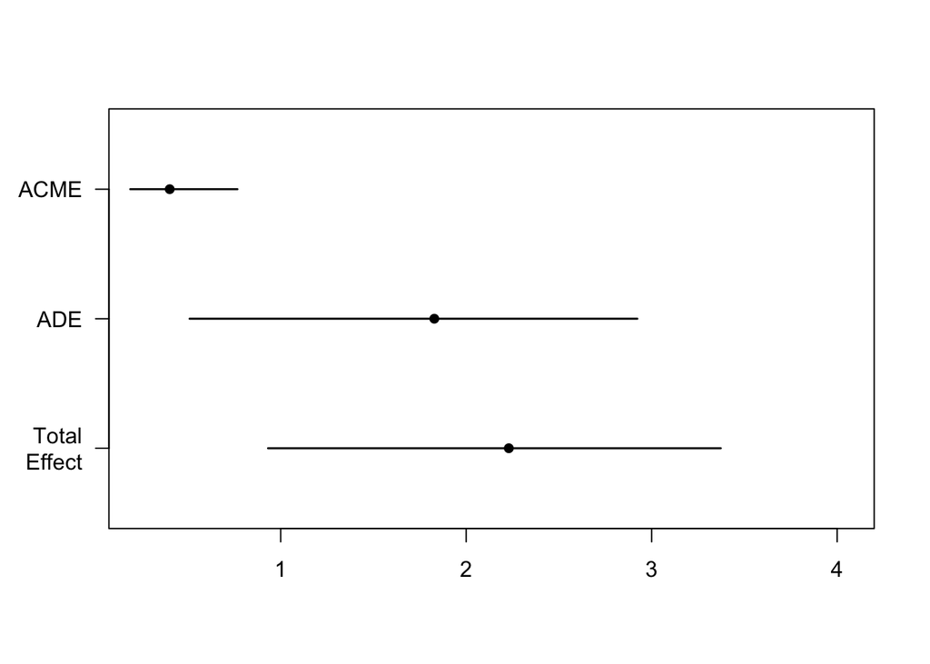

```r
plot(mediate_result)
```

```r
summary(mc,ci=TRUE)
```

```
##
## Call:
## lm(formula = BMI ~ RuralZIP_i + Gender3C + DEMO_Age_c + I(DEMO_Age_c^2) +
##     RaceC2 + aSES_02_z + PSS_z, data = data_to_measure)
##
## Residuals:
##     Min      1Q  Median      3Q     Max
## -15.009  -5.035  -1.331   4.310  36.640
##
## Coefficients:
##                                      Estimate Std. Error t value Pr(>|t|)
## (Intercept)                         2.726e+01  1.137e+00  23.978  < 2e-16 ***
## RuralZIP_i                          1.828e+00  6.113e-01   2.991 0.002897 **
## Gender3CMale                        8.964e-01  6.522e-01   1.374 0.169845
## DEMO_Age_c                          1.119e-02  1.678e-02   0.667 0.505073
## I(DEMO_Age_c^2)                    -1.181e-05  2.060e-05  -0.574 0.566502
## RaceC2HawaiianOtherPacificIslander  1.825e+00  1.999e+00   0.913 0.361549
## RaceC2HispanicAnyRace              -2.245e+00  1.661e+00  -1.351 0.177145
## RaceC2OtherRaceRaceNotReported     -5.123e-01  1.991e+00  -0.257 0.797006
## RaceC2WhiteOnly                     8.860e-01  1.146e+00   0.773 0.439808
## aSES_02_z                          -1.181e+00  3.055e-01  -3.865 0.000123 ***
## PSS_z                              -3.482e-01  3.173e-01  -1.097 0.272948
## ---
## Signif. codes:  0 '***' 0.001 '**' 0.01 '*' 0.05 '.' 0.1 ' ' 1
##
## Residual standard error: 7.219 on 602 degrees of freedom
##   (33 observations deleted due to missingness)
## Multiple R-squared:  0.0639, Adjusted R-squared:  0.04835
## F-statistic: 4.109 on 10 and 602 DF,  p-value: 1.687e-05
```

```r
set.seed(2498714)

library(mediation)

data_to_measure <- orfcs_dataset %>% dplyr::filter(!is.na(BMI)) %>% dplyr::filter(!is.na(BMI) & Gender3C %in% c("Male","Female"))

#Rurality -> Income -> BMI

mb <- lm(ZipcodeMedianHouseholdIncome~RuralZIP_i+Gender3C+DEMO_Age_c+I(DEMO_Age_c^2)+RaceC2+PSS_z#+
         ,data_to_measure)
mc <- lm(BMI~RuralZIP_i+Gender3C+DEMO_Age_c+I(DEMO_Age_c^2)+RaceC2+ZipcodeMedianHouseholdIncome+PSS_z#+
         ,data_to_measure)

mediate_result <- mediate(mb,mc,sims=boot_times,boot=TRUE,boot.ci.type = "bca",
                          treat="RuralZIP_i",mediator="ZipcodeMedianHouseholdIncome")
```

```
## Running nonparametric bootstrap
```

```r
summary(mediate_result,ci=TRUE)
```

```
##
## Causal Mediation Analysis
##
## Nonparametric Bootstrap Confidence Intervals with the BCa Method
##
##                Estimate 95% CI Lower 95% CI Upper p-value
## ACME              0.319       -0.207         0.83  0.2368
## ADE               1.929        0.466         3.21  0.0090 **
## Total Effect      2.248        0.937         3.37  0.0002 ***
## Prop. Mediated    0.142       -0.106         0.54  0.2370
## ---
## Signif. codes:  0 '***' 0.001 '**' 0.01 '*' 0.05 '.' 0.1 ' ' 1
##
## Sample Size Used: 616
##
##
## Simulations: 10000
```

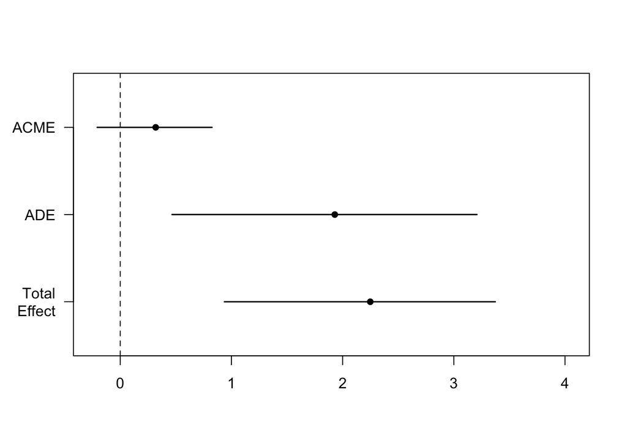

```r
plot(mediate_result,ci=TRUE)
```

```r
summary(mc,ci=TRUE)
```

```
##
## Call:
## lm(formula = BMI ~ RuralZIP_i + Gender3C + DEMO_Age_c + I(DEMO_Age_c^2) +
##     RaceC2 + ZipcodeMedianHouseholdIncome + PSS_z, data = data_to_measure)
##
## Residuals:
##     Min      1Q  Median      3Q     Max
## -14.630  -5.288  -1.264   4.118  36.418
##
## Coefficients:
##                                      Estimate Std. Error t value Pr(>|t|)
## (Intercept)                         2.876e+01  1.677e+00  17.145  < 2e-16 ***
## RuralZIP_i                          1.929e+00  6.711e-01   2.875  0.00418 **
## Gender3CMale                        4.955e-01  6.521e-01   0.760  0.44762
## DEMO_Age_c                          8.505e-03  1.700e-02   0.500  0.61710
## I(DEMO_Age_c^2)                    -8.841e-06  2.087e-05  -0.424  0.67202
## RaceC2HawaiianOtherPacificIslander  6.764e-01  2.020e+00   0.335  0.73782
## RaceC2HispanicAnyRace              -2.381e+00  1.670e+00  -1.426  0.15448
## RaceC2OtherRaceRaceNotReported     -1.547e+00  1.998e+00  -0.774  0.43909
## RaceC2WhiteOnly                     7.142e-01  1.159e+00   0.616  0.53788
## ZipcodeMedianHouseholdIncome       -2.067e-05  1.830e-05  -1.130  0.25906
## PSS_z                              -4.742e-01  3.181e-01  -1.491  0.13646
## ---
## Signif. codes:  0 '***' 0.001 '**' 0.01 '*' 0.05 '.' 0.1 ' ' 1
##
## Residual standard error: 7.308 on 605 degrees of freedom
##   (30 observations deleted due to missingness)
## Multiple R-squared:  0.0437, Adjusted R-squared:  0.02789
## F-statistic: 2.765 on 10 and 605 DF,  p-value: 0.002412
```

## Hours worked

Neither study records hours worked, although both record work status (full time/part time/unemployed). These would probably be predictive, but are not of particular interest, and I’m not aware of how we’d interpret this any differently to income, which is already included in the model.

# Pruning/regularization Oregon dataset

We can cut the dataset down, and perhaps observe slightly larger effects, by cutting the dataset down to size. Suitable rules might be:

- Include all possible pathways to start with
- Of the beta estimates with p>0.1 and which are not part of a p>0.1 pathway, remove the least significant
- Test for goodness of fit. If it’s an improvement, keep variable out and repeat. If it’s not an improvement, keep it in and repeat
- Repeat until there are no variables to take out.

- ```r
  oregon_full_model_template=
  "
    #Regressions
    aSES_02_z ~ ab*RuralZIP_i + DEMO_Age_c + DEMO_Age_c_pow2 + Gender3C_Male + Gender3C_Other + RaceC2_Asian + RaceC2_HawaiianOtherPacificIslander + RaceC2_HispanicAnyRace + RaceC2_OtherRaceRaceNotReported

    MESA_healthyfoodavailability_z ~ bc*aSES_02_z + ac*RuralZIP_i + DEMO_Age_c + DEMO_Age_c_pow2 + Gender3C_Male + Gender3C_Other + RaceC2_Asian + RaceC2_HawaiianOtherPacificIslander + RaceC2_HispanicAnyRace + RaceC2_OtherRaceRaceNotReported

    FFQ_fruit_vegetables_z ~ cd*MESA_healthyfoodavailability_z + bd*aSES_02_z + ad*RuralZIP_i + DEMO_Age_c + DEMO_Age_c_pow2 + Gender3C_Male + Gender3C_Other + RaceC2_Asian + RaceC2_HawaiianOtherPacificIslander + RaceC2_HispanicAnyRace + RaceC2_OtherRaceRaceNotReported

    (OUTCOMEVAR) ~ de*FFQ_fruit_vegetables_z + ce*MESA_healthyfoodavailability_z + be*aSES_02_z + ae*RuralZIP_i + DEMO_Age_c + DEMO_Age_c_pow2 + Gender3C_Male + Gender3C_Other + RaceC2_Asian + RaceC2_HawaiianOtherPacificIslander + RaceC2_HispanicAnyRace + RaceC2_OtherRaceRaceNotReported


    #Defined Parameters:
    indirect_effect := ab*bc*cd*de
    #cut one parameter
    effect_abce :=ab*bc*ce #makes no particular theoretical sense but for regularization rules, I want to observe it
    effect_via_food := ac*cd*de
    effect_via_inc_eating := ab*bd*de
    #cut two parameters
    effect_via_income := ab*be
    effect_ace := ac*ce
    effect_via_eating := ad*de
    #cut all mediators
    direct_effect := ae
  "

  # - Outcome: Physical and health measures. Altogether, we'll repeat the mediation several times, with the following outcomes variables: BMI, self-rated health, aggregated cardiometabolic health, and high blood pressure.

  outcome_measures <- c(
    "BMI"#,
    #"GeneralHealth_i",
    #"MedConditionsAggregate",
    #"MedConditions_HighBP_i",
    #"EverHadCancer_i"#no cancer for now, doesn't seem very important.
    )
  ```

OK, so we have set a full model. Let’s run the base full model in SEM and follow the steps above to do the first pruning iteration.

```r
library(performance)

# for (outcome_var in outcome_measures){
set.seed(8233042)
outcome_var <- "BMI"
oregon_model_w_outcome <- str_replace_all(oregon_full_model_template,"\\(OUTCOMEVAR\\)",outcome_var)
cat(paste0("MEDIATION MODEL FOR OUTCOME: ",outcome_var))
```

```
## MEDIATION MODEL FOR OUTCOME: BMI
```

```r
cat(oregon_model_w_outcome)
```

```
##
##   #Regressions
##   aSES_02_z ~ ab*RuralZIP_i + DEMO_Age_c + DEMO_Age_c_pow2 + Gender3C_Male + Gender3C_Other + RaceC2_Asian + RaceC2_HawaiianOtherPacificIslander + RaceC2_HispanicAnyRace + RaceC2_OtherRaceRaceNotReported
##
##   MESA_healthyfoodavailability_z ~ bc*aSES_02_z + ac*RuralZIP_i + DEMO_Age_c + DEMO_Age_c_pow2 + Gender3C_Male + Gender3C_Other + RaceC2_Asian + RaceC2_HawaiianOtherPacificIslander + RaceC2_HispanicAnyRace + RaceC2_OtherRaceRaceNotReported
##
##   FFQ_fruit_vegetables_z ~ cd*MESA_healthyfoodavailability_z + bd*aSES_02_z + ad*RuralZIP_i + DEMO_Age_c + DEMO_Age_c_pow2 + Gender3C_Male + Gender3C_Other + RaceC2_Asian + RaceC2_HawaiianOtherPacificIslander + RaceC2_HispanicAnyRace + RaceC2_OtherRaceRaceNotReported
##
##   BMI ~ de*FFQ_fruit_vegetables_z + ce*MESA_healthyfoodavailability_z + be*aSES_02_z + ae*RuralZIP_i + DEMO_Age_c + DEMO_Age_c_pow2 + Gender3C_Male + Gender3C_Other + RaceC2_Asian + RaceC2_HawaiianOtherPacificIslander + RaceC2_HispanicAnyRace + RaceC2_OtherRaceRaceNotReported
##
##
##   #Defined Parameters:
##   indirect_effect := ab*bc*cd*de
##   #cut one parameter
##   effect_abce :=ab*bc*ce #makes no particular theoretical sense but for regularization rules, I want to observe it
##   effect_via_food := ac*cd*de
##   effect_via_inc_eating := ab*bd*de
##   #cut two parameters
##   effect_via_income := ab*be
##   effect_ace := ac*ce
##   effect_via_eating := ad*de
##   #cut all mediators
##   direct_effect := ae
```

```r
orfcs_fit_full=sem(
  oregon_model_w_outcome,
  orfcs_dataset_pp,
  se = "bootstrap",
  bootstrap=boot_times,
  likelihood = "wishart")
```

[output not shown]

```r
summary(orfcs_fit_full,fit.measures=TRUE,ci=TRUE)
```

```
## lavaan 0.6-11 ended normally after 1 iterations
##
##   Estimator                                         ML
##   Optimization method                           NLMINB
##   Number of model parameters                        46
##
##                                                   Used       Total
##   Number of observations                           618         850
##
## Model Test User Model:
##
##   Test statistic                                 0.000
##   Degrees of freedom                                 0
##
## Model Test Baseline Model:
##
##   Test statistic                             38921.993
##   Degrees of freedom                                42
##   P-value                                        0.000
##
## User Model versus Baseline Model:
##
##   Comparative Fit Index (CFI)                    1.000
##   Tucker-Lewis Index (TLI)                       1.000
##
## Loglikelihood and Information Criteria:
##
##   Loglikelihood user model (H0)              -4665.135
##   Loglikelihood unrestricted model (H1)      -4665.135
##
##   Akaike (AIC)                                9422.269
##   Bayesian (BIC)                              9625.887
##   Sample-size adjusted Bayesian (BIC)         9479.846
##
## Root Mean Square Error of Approximation:
##
##   RMSEA                                          0.000
##   90 Percent confidence interval - lower         0.000
##   90 Percent confidence interval - upper         0.000
##   P-value RMSEA <= 0.05                             NA
```

[output cut: 123 more lines]

```
##     effect_via_fod          0.041    0.021    1.935    0.053          0.008
##     effct_v_nc_tng          0.014    0.016    0.891    0.373         -0.012
##     effect_via_ncm          0.350    0.139    2.514    0.012          0.138
##     effect_ace              0.088    0.096    0.916    0.360         -0.061
##     effect_via_tng         -0.109    0.091   -1.191    0.234         -0.320
##     direct_effect           1.583    0.630    2.511    0.012          0.268
##  ci.upper
##           0.019
##           0.070
##           0.090
##           0.053
##           0.683
##           0.322
##           0.044
##           2.755
```

```r
  # cat("-----\n\n\n")
# }
```

```r
model_performance(orfcs_fit_full,metrics = c("Chi2","AGFI","CFI","RMSEA","p_RMSEA","AIC","BIC","Loglikelihood"))
```

| Chi2 | AGFI | CFI | RMSEA | p_RMSEA | AIC | BIC | Loglikelihood |
| --- | --- | --- | --- | --- | --- | --- | --- |
| 0 | 1 | 1 | 0 | NA | 9422.269 | 9625.887 | -4665.135 |

OK. So now, let’s try removing something. Of the model variables, ce was the least significant. That’s the path directly from availability to outcomes, excluding consumption. So we’ll remove it, and try again.

## first pruning

````
```r
oregon_model_template_prune1=
"
  #Regressions
  aSES_02_z ~ ab*RuralZIP_i + DEMO_Age_c + DEMO_Age_c_pow2 + Gender3C_Male + Gender3C_Other + RaceC2_Asian + RaceC2_HawaiianOtherPacificIslander + RaceC2_HispanicAnyRace + RaceC2_OtherRaceRaceNotReported

  MESA_healthyfoodavailability_z ~ bc*aSES_02_z + ac*RuralZIP_i + DEMO_Age_c + DEMO_Age_c_pow2 + Gender3C_Male + Gender3C_Other + RaceC2_Asian + RaceC2_HawaiianOtherPacificIslander + RaceC2_HispanicAnyRace + RaceC2_OtherRaceRaceNotReported

  FFQ_fruit_vegetables_z ~ cd*MESA_healthyfoodavailability_z + bd*aSES_02_z + ad*RuralZIP_i + DEMO_Age_c + DEMO_Age_c_pow2 + Gender3C_Male + Gender3C_Other + RaceC2_Asian + RaceC2_HawaiianOtherPacificIslander + RaceC2_HispanicAnyRace + RaceC2_OtherRaceRaceNotReported

  (OUTCOMEVAR) ~ de*FFQ_fruit_vegetables_z #+ ce*MESA_healthyfoodavailability_z
           + be*aSES_02_z + ae*RuralZIP_i + DEMO_Age_c + DEMO_Age_c_pow2 + Gender3C_Male + Gender3C_Other + RaceC2_Asian + RaceC2_HawaiianOtherPacificIslander + RaceC2_HispanicAnyRace + RaceC2_OtherRaceRaceNotReported


  #Defined Parameters:
  indirect_effect := ab*bc*cd*de
  #cut one parameter
  #effect_abce :=ab*bc*ce #makes no particular theoretical sense but for regularization rules, I want to observe it
  effect_via_food := ac*cd*de
  effect_via_inc_eating := ab*bd*de
  #cut two parameters
  effect_via_income := ab*be
  #effect_ace := ac*ce
  effect_via_eating := ad*de
  #cut all mediators
  direct_effect := ae
"
```
````

```r
# for (outcome_var in outcome_measures){
set.seed(8233042)
outcome_var <- "BMI"
oregon_model_w_outcome <- str_replace_all(oregon_model_template_prune1,"\\(OUTCOMEVAR\\)",outcome_var)
cat(paste0("MEDIATION MODEL FOR OUTCOME: ",outcome_var))
```

```
## MEDIATION MODEL FOR OUTCOME: BMI
```

```r
cat(oregon_model_w_outcome)
```

```
##
##   #Regressions
##   aSES_02_z ~ ab*RuralZIP_i + DEMO_Age_c + DEMO_Age_c_pow2 + Gender3C_Male + Gender3C_Other + RaceC2_Asian + RaceC2_HawaiianOtherPacificIslander + RaceC2_HispanicAnyRace + RaceC2_OtherRaceRaceNotReported
##
##   MESA_healthyfoodavailability_z ~ bc*aSES_02_z + ac*RuralZIP_i + DEMO_Age_c + DEMO_Age_c_pow2 + Gender3C_Male + Gender3C_Other + RaceC2_Asian + RaceC2_HawaiianOtherPacificIslander + RaceC2_HispanicAnyRace + RaceC2_OtherRaceRaceNotReported
##
##   FFQ_fruit_vegetables_z ~ cd*MESA_healthyfoodavailability_z + bd*aSES_02_z + ad*RuralZIP_i + DEMO_Age_c + DEMO_Age_c_pow2 + Gender3C_Male + Gender3C_Other + RaceC2_Asian + RaceC2_HawaiianOtherPacificIslander + RaceC2_HispanicAnyRace + RaceC2_OtherRaceRaceNotReported
##
##   BMI ~ de*FFQ_fruit_vegetables_z #+ ce*MESA_healthyfoodavailability_z
##            + be*aSES_02_z + ae*RuralZIP_i + DEMO_Age_c + DEMO_Age_c_pow2 + Gender3C_Male + Gender3C_Other + RaceC2_Asian + RaceC2_HawaiianOtherPacificIslander + RaceC2_HispanicAnyRace + RaceC2_OtherRaceRaceNotReported
##
##
##   #Defined Parameters:
##   indirect_effect := ab*bc*cd*de
##   #cut one parameter
##   #effect_abce :=ab*bc*ce #makes no particular theoretical sense but for regularization rules, I want to observe it
##   effect_via_food := ac*cd*de
##   effect_via_inc_eating := ab*bd*de
##   #cut two parameters
##   effect_via_income := ab*be
##   #effect_ace := ac*ce
##   effect_via_eating := ad*de
##   #cut all mediators
##   direct_effect := ae
```

```r
orfcs_fit_prune1=sem(
  oregon_model_w_outcome,
  orfcs_dataset_pp,
  se = "bootstrap",
  bootstrap=boot_times,
  likelihood = "wishart")
```

[output not shown]

```r
summary(orfcs_fit_prune1,ci=TRUE)
```

```
## lavaan 0.6-11 ended normally after 1 iterations
##
##   Estimator                                         ML
##   Optimization method                           NLMINB
##   Number of model parameters                        45
##
##                                                   Used       Total
##   Number of observations                           618         850
##
## Model Test User Model:
##
##   Test statistic                                 1.110
##   Degrees of freedom                                 1
##   P-value (Chi-square)                           0.292
##
## Parameter Estimates:
##
##   Standard errors                            Bootstrap
##   Number of requested bootstrap draws            10000
##   Number of successful bootstrap draws            9921
##
## Regressions:
##                                    Estimate        Std.Err  z-value  P(>|z|)
##   aSES_02_z ~
##     RuralZIP_ (ab)                         -0.352    0.078   -4.496    0.000
##     DEMO_Ag_c                               0.001    0.002    0.496    0.620
##     DEMO_A__2                              -0.000    0.000   -0.008    0.993
##     Gndr3C_Ml                               0.352    0.087    4.054    0.000
##     Gndr3C_Ot                               0.026    0.347    0.074    0.941
##     RacC2_Asn                              -0.214    0.163   -1.311    0.190
##     RcC2_HOPI                               0.304    0.253    1.203    0.229
##     RcC2_HsAR                               0.097    0.178    0.548    0.583
##     RC2_ORRNR                               0.703    0.196    3.596    0.000
##   MESA_healthyfoodavailability_z ~
##     aSES_02_z (bc)                          0.167    0.040    4.169    0.000
##     RuralZIP_ (ac)                         -0.272    0.086   -3.155    0.002
##     DEMO_Ag_c                               0.006    0.002    3.085    0.002
##     DEMO_A__2                              -0.000    0.000   -0.069    0.945
##     Gndr3C_Ml                              -0.057    0.087   -0.655    0.512
##     Gndr3C_Ot                              -0.082    0.336   -0.245    0.806
```

[output cut: 87 more lines]

```
## Defined Parameters:
##                    Estimate        Std.Err  z-value  P(>|z|) ci.lower
##     indirect_effct          0.009    0.005    1.940    0.052          0.002
##     effect_via_fod          0.043    0.022    1.926    0.054          0.009
##     effct_v_nc_tng          0.015    0.017    0.893    0.372         -0.012
##     effect_via_ncm          0.368    0.143    2.584    0.010          0.154
##     effect_via_tng         -0.114    0.095   -1.195    0.232         -0.333
##     direct_effect           1.674    0.621    2.696    0.007          0.396
##  ci.upper
##           0.020
##           0.095
##           0.056
##           0.707
##           0.046
##           2.842
```

```r
  # cat("-----\n\n\n")
# }
```

```r
compare_performance(orfcs_fit_full,orfcs_fit_prune1,metrics = c("Chi2","AGFI","CFI","RMSEA","p_RMSEA","AIC","BIC","Loglikelihood"))
```

| Name | Model | Chi2 | AGFI | CFI | RMSEA | p_RMSEA | AIC | AIC_wt | BIC | BIC_wt | Loglikelihood |
| --- | --- | --- | --- | --- | --- | --- | --- | --- | --- | --- | --- |
| orfcs_fit_full | lavaan | 0.000000 | 1.0000000 | 1.0000000 | 0.00000000 | NA | 9422.269 | 0.3907673 | 9625.887 | 0.06553853 | -4665.135 |
| orfcs_fit_prune1 | lavaan | 1.110025 | 0.9185339 | 0.9999972 | 0.01335375 | 0.585568 | 9421.381 | 0.6092327 | 9620.573 | 0.93446147 | -4665.690 |

OK, the model looks good, and on BIC, the pruned model is an improvement. so let’s cut out another variable.

Examinig the data, the next one to cut is bd, linking income to eating behavior (bypassing food availability). This is in one pathway, “effect via income and eating”, and that pathway is not significant (p>0.1). So we remove it and try again.

## Second pruning

````
```r
oregon_model_template_prune2=
"
  #Regressions
  aSES_02_z ~ ab*RuralZIP_i + DEMO_Age_c + DEMO_Age_c_pow2 + Gender3C_Male + Gender3C_Other + RaceC2_Asian + RaceC2_HawaiianOtherPacificIslander + RaceC2_HispanicAnyRace + RaceC2_OtherRaceRaceNotReported

  MESA_healthyfoodavailability_z ~ bc*aSES_02_z + ac*RuralZIP_i + DEMO_Age_c + DEMO_Age_c_pow2 + Gender3C_Male + Gender3C_Other + RaceC2_Asian + RaceC2_HawaiianOtherPacificIslander + RaceC2_HispanicAnyRace + RaceC2_OtherRaceRaceNotReported

  FFQ_fruit_vegetables_z ~ cd*MESA_healthyfoodavailability_z + #bd*aSES_02_z +
                        ad*RuralZIP_i + DEMO_Age_c + DEMO_Age_c_pow2 + Gender3C_Male + Gender3C_Other + RaceC2_Asian + RaceC2_HawaiianOtherPacificIslander + RaceC2_HispanicAnyRace + RaceC2_OtherRaceRaceNotReported

  (OUTCOMEVAR) ~ de*FFQ_fruit_vegetables_z #+ ce*MESA_healthyfoodavailability_z
           + be*aSES_02_z + ae*RuralZIP_i + DEMO_Age_c + DEMO_Age_c_pow2 + Gender3C_Male + Gender3C_Other + RaceC2_Asian + RaceC2_HawaiianOtherPacificIslander + RaceC2_HispanicAnyRace + RaceC2_OtherRaceRaceNotReported


  #Defined Parameters:
  indirect_effect := ab*bc*cd*de
  #cut one parameter
  #effect_abce :=ab*bc*ce #makes no particular theoretical sense but for regularization rules, I want to observe it
  effect_via_food := ac*cd*de
  #effect_via_inc_eating := ab*bd*de
  #cut two parameters
  effect_via_income := ab*be
  #effect_ace := ac*ce
  effect_via_eating := ad*de
  #cut all mediators
  direct_effect := ae
"
```
````

```r
# for (outcome_var in outcome_measures){
set.seed(8233042)
outcome_var <- "BMI"
oregon_model_w_outcome <- str_replace_all(oregon_model_template_prune2,"\\(OUTCOMEVAR\\)",outcome_var)
cat(paste0("MEDIATION MODEL FOR OUTCOME: ",outcome_var))
```

```
## MEDIATION MODEL FOR OUTCOME: BMI
```

```r
cat(oregon_model_w_outcome)
```

```
##
##   #Regressions
##   aSES_02_z ~ ab*RuralZIP_i + DEMO_Age_c + DEMO_Age_c_pow2 + Gender3C_Male + Gender3C_Other + RaceC2_Asian + RaceC2_HawaiianOtherPacificIslander + RaceC2_HispanicAnyRace + RaceC2_OtherRaceRaceNotReported
##
##   MESA_healthyfoodavailability_z ~ bc*aSES_02_z + ac*RuralZIP_i + DEMO_Age_c + DEMO_Age_c_pow2 + Gender3C_Male + Gender3C_Other + RaceC2_Asian + RaceC2_HawaiianOtherPacificIslander + RaceC2_HispanicAnyRace + RaceC2_OtherRaceRaceNotReported
##
##   FFQ_fruit_vegetables_z ~ cd*MESA_healthyfoodavailability_z + #bd*aSES_02_z +
##                         ad*RuralZIP_i + DEMO_Age_c + DEMO_Age_c_pow2 + Gender3C_Male + Gender3C_Other + RaceC2_Asian + RaceC2_HawaiianOtherPacificIslander + RaceC2_HispanicAnyRace + RaceC2_OtherRaceRaceNotReported
##
##   BMI ~ de*FFQ_fruit_vegetables_z #+ ce*MESA_healthyfoodavailability_z
##            + be*aSES_02_z + ae*RuralZIP_i + DEMO_Age_c + DEMO_Age_c_pow2 + Gender3C_Male + Gender3C_Other + RaceC2_Asian + RaceC2_HawaiianOtherPacificIslander + RaceC2_HispanicAnyRace + RaceC2_OtherRaceRaceNotReported
##
##
##   #Defined Parameters:
##   indirect_effect := ab*bc*cd*de
##   #cut one parameter
##   #effect_abce :=ab*bc*ce #makes no particular theoretical sense but for regularization rules, I want to observe it
##   effect_via_food := ac*cd*de
##   #effect_via_inc_eating := ab*bd*de
##   #cut two parameters
##   effect_via_income := ab*be
##   #effect_ace := ac*ce
##   effect_via_eating := ad*de
##   #cut all mediators
##   direct_effect := ae
```

```r
orfcs_fit_prune2=sem(
  oregon_model_w_outcome,
  orfcs_dataset_pp,
  se = "bootstrap",
  bootstrap=boot_times,
  likelihood = "wishart")
```

[output not shown]

[output cut: 28 more lines]

[output not shown]

```r
summary(orfcs_fit_prune2,ci=TRUE)
```

```
## lavaan 0.6-11 ended normally after 1 iterations
##
##   Estimator                                         ML
##   Optimization method                           NLMINB
##   Number of model parameters                        44
##
##                                                   Used       Total
##   Number of observations                           618         850
##
## Model Test User Model:
##
##   Test statistic                                 2.110
##   Degrees of freedom                                 2
##   P-value (Chi-square)                           0.348
##
## Parameter Estimates:
##
##   Standard errors                            Bootstrap
##   Number of requested bootstrap draws            10000
##   Number of successful bootstrap draws            9917
##
## Regressions:
##                                    Estimate        Std.Err  z-value  P(>|z|)
##   aSES_02_z ~
##     RuralZIP_ (ab)                         -0.352    0.078   -4.497    0.000
##     DEMO_Ag_c                               0.001    0.002    0.496    0.620
##     DEMO_A__2                              -0.000    0.000   -0.008    0.993
##     Gndr3C_Ml                               0.352    0.087    4.052    0.000
##     Gndr3C_Ot                               0.026    0.348    0.074    0.941
##     RacC2_Asn                              -0.214    0.163   -1.310    0.190
##     RcC2_HOPI                               0.304    0.253    1.203    0.229
##     RcC2_HsAR                               0.097    0.178    0.548    0.584
##     RC2_ORRNR                               0.703    0.196    3.598    0.000
##   MESA_healthyfoodavailability_z ~
##     aSES_02_z (bc)                          0.167    0.040    4.165    0.000
##     RuralZIP_ (ac)                         -0.272    0.086   -3.155    0.002
##     DEMO_Ag_c                               0.006    0.002    3.085    0.002
##     DEMO_A__2                              -0.000    0.000   -0.069    0.945
##     Gndr3C_Ml                              -0.057    0.087   -0.656    0.512
##     Gndr3C_Ot                              -0.082    0.336   -0.245    0.806
```

[output cut: 83 more lines]

```
##          59.312
##
## Defined Parameters:
##                    Estimate        Std.Err  z-value  P(>|z|) ci.lower
##     indirect_effct          0.010    0.005    1.958    0.050          0.002
##     effect_via_fod          0.045    0.023    1.975    0.048          0.010
##     effect_via_ncm          0.368    0.143    2.584    0.010          0.154
##     effect_via_tng         -0.101    0.093   -1.090    0.276         -0.313
##     direct_effect           1.674    0.621    2.695    0.007          0.395
##  ci.upper
##           0.021
##           0.097
##           0.707
##           0.058
##           2.842
```

```r
  # cat("-----\n\n\n")
# }
```

```r
compare_performance(orfcs_fit_full,orfcs_fit_prune1,orfcs_fit_prune2,metrics = c("Chi2","AGFI","CFI","RMSEA","p_RMSEA","AIC","BIC","Loglikelihood"))
```

| Name | Model | Chi2 | AGFI | CFI | RMSEA | p_RMSEA | AIC | AIC_wt | BIC | BIC_wt | Loglikelihood |
| --- | --- | --- | --- | --- | --- | --- | --- | --- | --- | --- | --- |
| orfcs_fit_full | lavaan | 0.000000 | 1.0000000 | 1.0000000 | 0.000000000 | NA | 9422.269 | 0.1950393 | 9625.887 | 0.004346931 | -4665.135 |
| orfcs_fit_prune1 | lavaan | 1.110025 | 0.9185339 | 0.9999972 | 0.013353752 | 0.5855680 | 9421.381 | 0.3040794 | 9620.573 | 0.061979415 | -4665.690 |
| orfcs_fit_prune2 | lavaan | 2.110243 | 0.9225311 | 0.9999972 | 0.009451867 | 0.7404853 | 9420.383 | 0.5008813 | 9615.148 | 0.933673654 | -4666.191 |

The next pruning again looks like an improvement on BIC and mabye on AIC. So we can proceed to a third pruning. Direct effect of rurality on eating, `ad`, isn’t significant, and neither is the path that uses it. So we can eliminate it and try again.

## Third pruning

````
```r
oregon_model_template_prune3=
"
  #Regressions
  aSES_02_z ~ ab*RuralZIP_i + DEMO_Age_c + DEMO_Age_c_pow2 + Gender3C_Male + Gender3C_Other + RaceC2_Asian + RaceC2_HawaiianOtherPacificIslander + RaceC2_HispanicAnyRace + RaceC2_OtherRaceRaceNotReported

  MESA_healthyfoodavailability_z ~ bc*aSES_02_z + ac*RuralZIP_i + DEMO_Age_c + DEMO_Age_c_pow2 + Gender3C_Male + Gender3C_Other + RaceC2_Asian + RaceC2_HawaiianOtherPacificIslander + RaceC2_HispanicAnyRace + RaceC2_OtherRaceRaceNotReported

  FFQ_fruit_vegetables_z ~ cd*MESA_healthyfoodavailability_z + #bd*aSES_02_z + ad*RuralZIP_i +
                      DEMO_Age_c + DEMO_Age_c_pow2 + Gender3C_Male + Gender3C_Other + RaceC2_Asian + RaceC2_HawaiianOtherPacificIslander + RaceC2_HispanicAnyRace + RaceC2_OtherRaceRaceNotReported

  (OUTCOMEVAR) ~ de*FFQ_fruit_vegetables_z #+ ce*MESA_healthyfoodavailability_z
           + be*aSES_02_z + ae*RuralZIP_i + DEMO_Age_c + DEMO_Age_c_pow2 + Gender3C_Male + Gender3C_Other + RaceC2_Asian + RaceC2_HawaiianOtherPacificIslander + RaceC2_HispanicAnyRace + RaceC2_OtherRaceRaceNotReported


  #Defined Parameters:
  indirect_effect := ab*bc*cd*de
  #cut one parameter
  #effect_abce :=ab*bc*ce #makes no particular theoretical sense but for regularization rules, I want to observe it
  effect_via_food := ac*cd*de
  #effect_via_inc_eating := ab*bd*de
  #cut two parameters
  effect_via_income := ab*be
  #effect_ace := ac*ce
  #effect_via_eating := ad*de
  #cut all mediators
  direct_effect := ae
"
```
````

```r
# for (outcome_var in outcome_measures){
set.seed(8233042)
outcome_var <- "BMI"
cat(paste0("MEDIATION MODEL FOR OUTCOME: ",outcome_var))
```

```
## MEDIATION MODEL FOR OUTCOME: BMI
```

```r
cat(oregon_model_w_outcome)
```

[output not shown]

```r
oregon_model_w_outcome <- str_replace_all(oregon_model_template_prune3,"\\(OUTCOMEVAR\\)",outcome_var)
orfcs_fit_prune3=sem(
  oregon_model_w_outcome,
  orfcs_dataset_pp,
  se = "bootstrap",
  bootstrap=boot_times,
  likelihood = "wishart")
```

[output not shown]

```r
summary(orfcs_fit_prune3,fit.measures=TRUE,ci=TRUE)
```

```
## lavaan 0.6-11 ended normally after 1 iterations
##
##   Estimator                                         ML
##   Optimization method                           NLMINB
##   Number of model parameters                        43
##
##                                                   Used       Total
##   Number of observations                           618         850
##
## Model Test User Model:
##
##   Test statistic                                 3.531
##   Degrees of freedom                                 3
##   P-value (Chi-square)                           0.317
##
## Model Test Baseline Model:
##
##   Test statistic                             38921.993
##   Degrees of freedom                                42
##   P-value                                        0.000
##
## User Model versus Baseline Model:
##
##   Comparative Fit Index (CFI)                    1.000
##   Tucker-Lewis Index (TLI)                       1.000
##
## Loglikelihood and Information Criteria:
##
##   Loglikelihood user model (H0)              -4666.903
##   Loglikelihood unrestricted model (H1)      -4665.135
##
##   Akaike (AIC)                                9419.805
##   Bayesian (BIC)                              9610.144
##   Sample-size adjusted Bayesian (BIC)         9473.627
##
## Root Mean Square Error of Approximation:
##
##   RMSEA                                          0.017
##   90 Percent confidence interval - lower         0.000
##   90 Percent confidence interval - upper         0.072
```

[output cut: 110 more lines]

```
##           1.014
##           1.050
##          59.311
##
## Defined Parameters:
##                    Estimate        Std.Err  z-value  P(>|z|) ci.lower
##     indirect_effct          0.009    0.005    1.937    0.053          0.002
##     effect_via_fod          0.043    0.021    1.985    0.047          0.009
##     effect_via_ncm          0.368    0.143    2.584    0.010          0.154
##     direct_effect           1.674    0.621    2.696    0.007          0.396
##  ci.upper
##           0.020
##           0.092
##           0.707
##           2.842
```

```r
  # cat("-----\n\n\n")
# }
```

```r
compare_performance(
  orfcs_fit_full,
  orfcs_fit_prune1,
  orfcs_fit_prune2,
  orfcs_fit_prune3,
  metrics = c("Chi2","AGFI","CFI","RMSEA","p_RMSEA","AIC","BIC","Loglikelihood"))
```

| Name | Model | Chi2 | AGFI | CFI | RMSEA | p_RMSEA | AIC | AIC_wt | BIC | BIC_wt | Loglikelihood |
| --- | --- | --- | --- | --- | --- | --- | --- | --- | --- | --- | --- |
| orfcs_fit_full | lavaan | 0.000000 | 1.0000000 | 1.0000000 | 0.000000000 | NA | 9422.269 | 0.1168931 | 9625.887 | 0.0003506527 | -4665.135 |
| orfcs_fit_prune1 | lavaan | 1.110025 | 0.9185339 | 0.9999972 | 0.013353752 | 0.5855680 | 9421.381 | 0.1822443 | 9620.573 | 0.0049996764 | -4665.690 |
| orfcs_fit_prune2 | lavaan | 2.110243 | 0.9225311 | 0.9999972 | 0.009451867 | 0.7404853 | 9420.383 | 0.3001938 | 9615.148 | 0.0753163953 | -4666.191 |
| orfcs_fit_prune3 | lavaan | 3.530528 | 0.9138335 | 0.9999864 | 0.016929765 | 0.7859457 | 9419.805 | 0.4006688 | 9610.144 | 0.9193332756 | -4666.903 |

At least according to BIC, this model is a better fit. All remaining path variables are significant, and remaining paths are either significant or marginally significant, so that’s as far as it goes.

Knowing all of this, perhaps it’s not a big deal for the HINTS dataset that it doesn’t have separate variables for consumption and availability. they seem quite related.